# Causal Inference Lab 6: Weighting, and Balance

## Overview

In this lab, we move from the theory of weighting to a practical application using the LaLonde-Dehejia-Wahba (LDW) data. The main goal is to see how different estimators behave when treated and control units are not directly comparable.

We will focus on four ideas:

1. **Balance** as the design target.
2. **Propensity scores** as a balancing score and overlap diagnostic.
3. **Weighting estimators** such as IPW, CBPS, and entropy balancing.
4. **Estimator comparison** on the LaLonde data.

A practical note: the comparison functions from the Imbens-Xu tutorial are written for the **ATT**. To stay consistent with that workflow, the estimator comparison section below also focuses on the ATT.

## Setup

```r
knitr::opts_chunk$set(fig.width = 7, fig.height = 4.5)

required_packages <- c(
  "tidyverse",
  "estimatr",
  "grf",
  "CBPS",
  "hbal"
)

missing_packages <- required_packages[!required_packages %in% rownames(installed.packages())]
if (length(missing_packages) > 0) {
  install.packages(missing_packages)
}

library(tidyverse)
library(estimatr)
library(grf)
library(CBPS)
library(hbal)

# Source the tutorial helper functions
source("https://raw.githubusercontent.com/xuyiqing/lalonde/main/tutorial/functions.R")

# Download the LDW data if it is not already in your working directory
if (!file.exists("lalonde.RData")) {
  download.file(
    url = "https://raw.githubusercontent.com/xuyiqing/lalonde/main/tutorial/data/lalonde.RData",
    destfile = "lalonde.RData",
    mode = "wb"
  )
}

load("lalonde.RData")

# Variables used throughout the lab
Y <- "re78"
treat <- "treat"
covar <- c(
  "age", "education", "black", "hispanic", "married",
  "nodegree", "re74", "re75", "u74", "u75"
)
```

## 1. Meet the data

The loaded file contains several datasets. The two most useful for this lab are:

- `ldw`: the experimental LDW sample.
- `ldw_cps`: the treated LDW units combined with nonexperimental CPS controls.

The experimental sample gives us a useful benchmark, while `ldw_cps` is the observational sample where design problems are much more visible.

```r
tibble(
  sample = c("LDW experimental", "LDW-CPS1"),
  n = c(nrow(ldw), nrow(ldw_cps)),
  treated = c(sum(ldw$treat == 1), sum(ldw_cps$treat == 1)),
  control = c(sum(ldw$treat == 0), sum(ldw_cps$treat == 0))
)
```

```
## # A tibble: 2 × 4
##   sample               n treated control
##   <chr>            <int>   <int>   <int>
## 1 LDW experimental   445     185     260
## 2 LDW-CPS1         16177     185   15992
```

```r
ldw_cps %>%
  dplyr::select(treat, all_of(covar), all_of(Y)) %>%
  slice(1:6)
```

```
##   treat age education black hispanic married nodegree re74 re75 u74 u75
## 1     1  37        11     1        0       1        1    0    0   1   1
## 2     1  22         9     0        1       0        1    0    0   1   1
## 3     1  30        12     1        0       0        0    0    0   1   1
## 4     1  27        11     1        0       0        1    0    0   1   1
## 5     1  33         8     1        0       0        1    0    0   1   1
## 6     1  22         9     1        0       0        1    0    0   1   1
##         re78
## 1  9930.0459
## 2  3595.8940
## 3 24909.4492
## 4  7506.1460
## 5   289.7899
## 6  4056.4939
```

## 2. A simple benchmark: difference in means

We start with the raw treated-control difference in earnings in 1978.

```r
diff(ldw, Y, treat)
```

```
##   Estimate Std. Error   CI Lower   CI Upper
##  1794.3424   670.8245   475.9486  3112.7362
```

```r
diff(ldw_cps, Y, treat)
```

```
##   Estimate Std. Error   CI Lower   CI Upper
## -8497.5161   581.9158 -9638.1355 -7356.8968
```

The first estimate comes from the experimental sample; the second comes from the observational sample. The gap between them already tells us that naive comparisons can move a lot once the control group changes.

## 3. Why propensity scores help as a diagnostic

A key problem in observational data is that overlap is hard to inspect in a 10-dimensional covariate space. The propensity score compresses those covariates into a single number,

$$\hat e(X_i) = \widehat{P}(T_i = 1 \mid X_i),$$

which makes overlap easier to visualize.

### 3.1 Before the propensity score: raw covariate distributions

Here we compare a few important covariates directly.

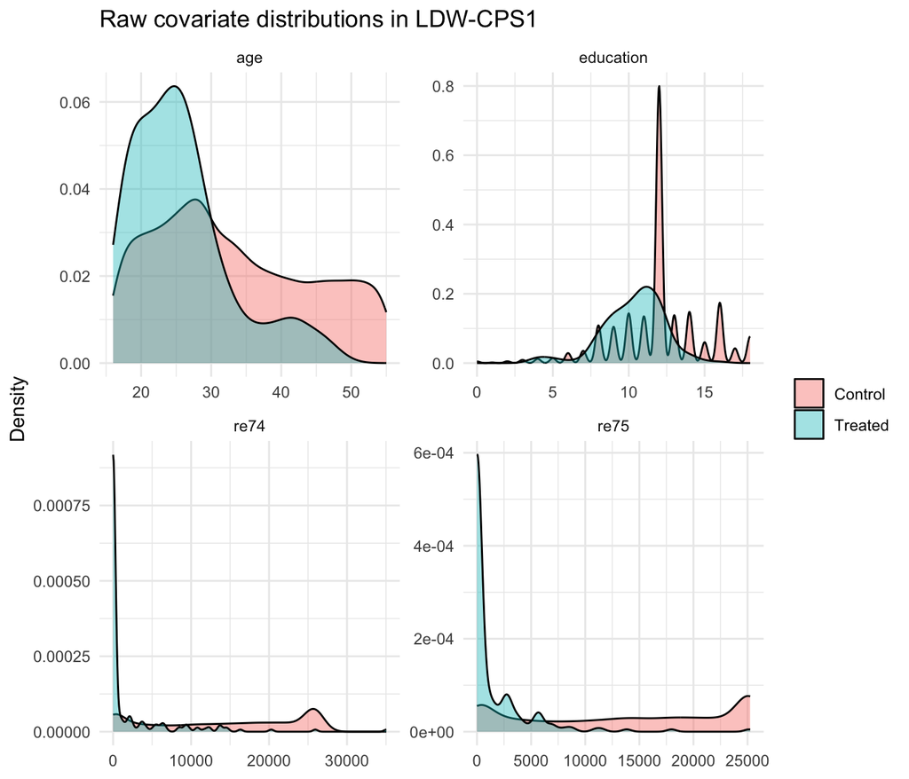

```r
plot_df <- ldw_cps %>%
  dplyr::select(treat, age, education, re74, re75) %>%
  pivot_longer(cols = c(age, education, re74, re75),
               names_to = "variable", values_to = "value") %>%
  mutate(group = if_else(treat == 1, "Treated", "Control"))

ggplot(plot_df, aes(x = value, fill = group)) +
  geom_density(alpha = 0.4) +
  facet_wrap(~ variable, scales = "free", ncol = 2) +
  labs(
    title = "Raw covariate distributions in LDW-CPS1",
    x = NULL,
    y = "Density",
    fill = NULL
  ) +
  theme_minimal()
```

This is already useful, but it is still a collection of separate univariate views. It does not solve the multivariate overlap problem.

### 3.2 With the propensity score: one-dimensional overlap plots

```r
par(mfrow = c(1, 2))
ldw_ps <- assess_overlap(data = ldw, treat = treat, cov = covar)
```

```
## -1.310867 0.7158619
```

```r
ldw_cps_ps <- assess_overlap(data = ldw_cps, treat = treat, cov = covar)
```

```
## -16.1181 1.787343
```

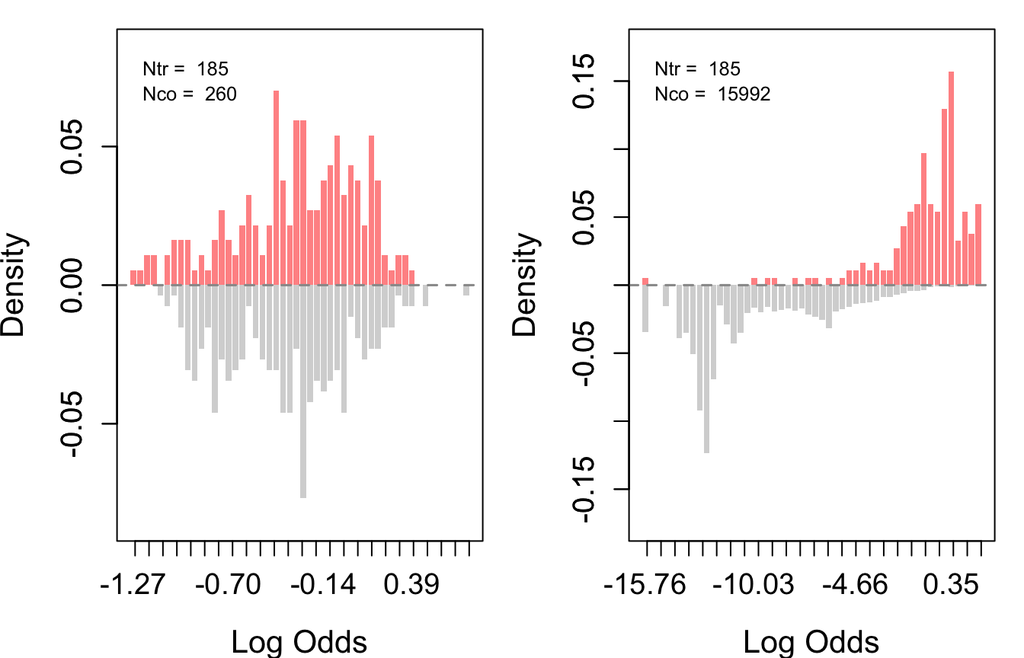

The experimental sample should show much better overlap than the observational LDW-CPS1 sample.

**Important:** the propensity score does **not create** overlap where there is no support. What it does is compress the covariates into a balancing score, which makes lack of common support easier to diagnose.

## 4. A manual propensity score weighting example

The tutorial’s `ipw()` function estimates ATT weights using a probability forest. Here we reproduce the same basic logic step by step so you can see what the weights are doing.

For the ATT, treated units receive weight 1, and controls receive

$$\frac{\hat e_i}{1-\hat e_i}.$$

```r
ps_model <- probability_forest(
  X = ldw_cps[, covar, drop = FALSE],
  Y = as.factor(ldw_cps[, treat]),
  seed = 1234
)

ldw_cps$ps_hat <- ps_model$predictions[, 2]
ldw_cps$w_att_ipw <- ifelse(ldw_cps$treat == 1, 1, ldw_cps$ps_hat / (1 - ldw_cps$ps_hat))

summary(ldw_cps$ps_hat)
```

```
##      Min.   1st Qu.    Median      Mean   3rd Qu.      Max.
## 0.0000000 0.0000024 0.0000106 0.0113662 0.0006648 0.8566012
```

```r
summary(ldw_cps$w_att_ipw)
```

```
##     Min.  1st Qu.   Median     Mean  3rd Qu.     Max.
## 0.000000 0.000002 0.000011 0.022219 0.000668 5.973557
```

Now use those ATT weights in a weighted regression of the outcome on treatment.

```r
ipw_manual <- lm_robust(re78 ~ treat, data = ldw_cps, weights = w_att_ipw, se_type = "stata")
summary(ipw_manual)$coefficients["treat", ]
```

```
##      Estimate    Std. Error       t value      Pr(>|t|)      CI Lower
##  1.223770e+03  6.894344e+02  1.775034e+00  7.591103e-02 -1.275980e+02
##      CI Upper            DF
##  2.575138e+03  1.617500e+04
```

### 4.1 Did weighting improve balance?

A quick way to see this is to compare treated means to control means before and after weighting.

```r
weighted_mean <- function(x, w) {
  sum(x * w) / sum(w)
}

balance_tbl <- map_dfr(covar, function(v) {
  x <- ldw_cps[[v]]
  treated <- ldw_cps$treat == 1
  control <- ldw_cps$treat == 0

  tibble(
    variable = v,
    treated_mean = mean(x[treated]),
    control_mean_unweighted = mean(x[control]),
    control_mean_weighted = weighted_mean(x[control], ldw_cps$w_att_ipw[control])
  )
})

balance_tbl
```

```
## # A tibble: 10 × 4
##    variable  treated_mean control_mean_unweighted control_mean_weighted
##    <chr>            <dbl>                   <dbl>                 <dbl>
##  1 age            25.8                    33.2                  27.1
##  2 education      10.3                    12.0                  10.6
##  3 black           0.843                   0.0735                0.841
##  4 hispanic        0.0595                  0.0720                0.0439
##  5 married         0.189                   0.712                 0.252
##  6 nodegree        0.708                   0.296                 0.628
##  7 re74         2096.                  14017.                 2053.
##  8 re75         1532.                  13651.                 1875.
##  9 u74             0.708                   0.120                 0.684
## 10 u75             0.600                   0.109                 0.567
```

The weighted control means should usually move closer to the treated means. That is the design goal of weighting.

## 5. Regression versus outcome modeling using regression

These two methods sound similar but they are doing different things.

### Regression adjustment (`reg`)

This fits one outcome model to the full sample:

$$Y_i = \alpha + \tau T_i + X_i'\beta + u_i.$$

The estimated treatment effect is the coefficient on `treat`.

### Outcome modeling using regression (`om.reg`)

This fits an outcome model **only among the controls**:

$$Y_i = \alpha + X_i'\beta + u_i \qquad \text{for } T_i = 0,$$

then uses that fitted model to predict the untreated outcomes for the treated units. The ATT is estimated by comparing:

- the observed treated outcomes, and
- the predicted untreated outcomes for those same treated units.

So the difference is:

- `reg` adjusts for covariates in **one pooled regression**.
- `om.reg` uses the controls to **impute the treated units’ counterfactual untreated outcome**.

## 6. Estimator comparison on LDW-CPS1

Now we reproduce a simplified version of the comparison figure from the tutorial using only the methods requested for this lab:

- `diff`
- `reg`
- `om.reg`
- `ipw`
- `cbps`
- `ebal`

```r
methods_keep <- c("diff", "reg", "om.reg", "ipw", "cbps", "ebal")
labels_keep <- c("Diff-in-Means", "Reg", "OM: Reg", "IPW", "CBPS", "Ebal")

# Experimental benchmark
out_exp <- estimate_all(
  data = ldw,
  Y = Y,
  treat = treat,
  covar = covar,
  methods = methods_keep
)

# Observational sample
out_cps <- estimate_all(
  data = ldw_cps,
  Y = Y,
  treat = treat,
  covar = covar,
  methods = methods_keep
)

out_exp
```

```
##        Estimate       SE CI_lower CI_upper
## diff   1794.342 670.8245 475.9486 3112.736
## reg    1670.709 680.2010 333.8025 3007.615
## om.reg 1706.204 587.9401 550.0597 2862.347
## ipw    1774.707 680.0116 438.2579 3111.157
## cbps   1748.455 697.0474 378.5244 3118.385
## ebal   1712.119 699.2609 337.8380 3086.400
```

```r
out_cps
```

```
##         Estimate       SE    CI_lower  CI_upper
## diff   -8497.516 581.9158 -9638.13549 -7356.897
## reg     1066.376 626.8479  -162.31501  2295.068
## om.reg  1133.275 624.2600   -94.28907  2360.840
## ipw     1223.770 689.4344  -127.59802  2575.138
## cbps    1342.895 649.9350    68.95054  2616.840
## ebal    1406.270 654.9275   122.53981  2690.001
```

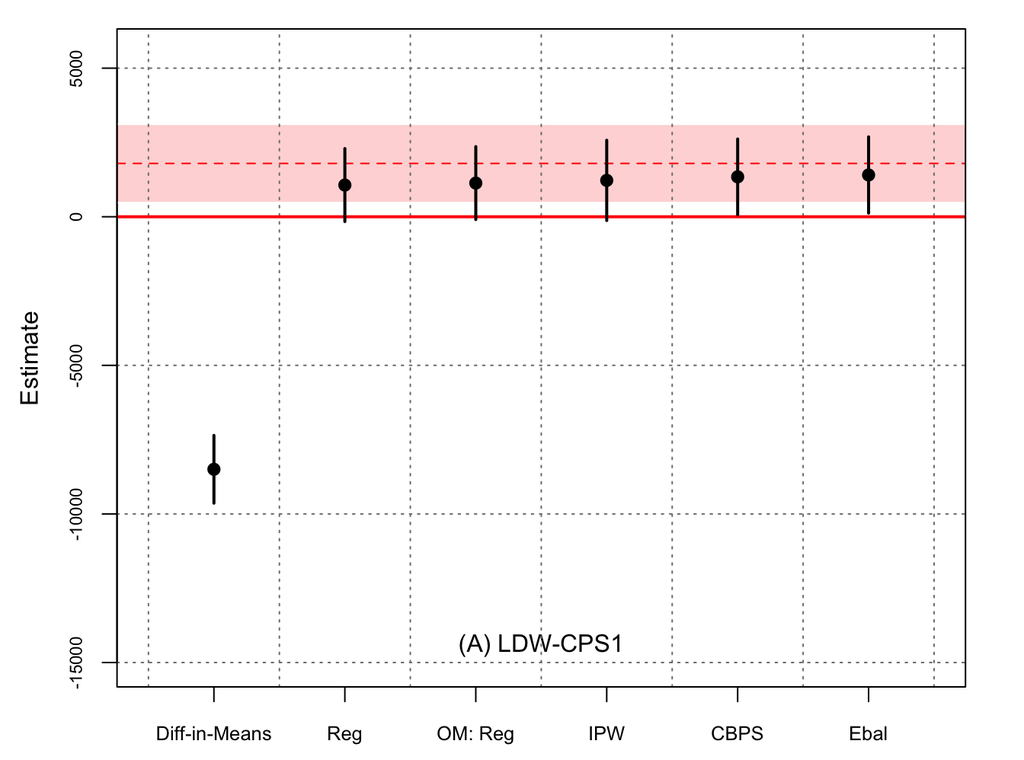

```r
par(mfrow = c(1, 1))

benchmark_band <- out_exp["diff", c("CI_lower", "CI_upper")]
benchmark_line <- out_exp["diff", "Estimate"]

plot_coef(
  out = out_cps,
  methods = methods_keep,
  labels = labels_keep,
  band = benchmark_band,
  line = benchmark_line,
  ylim = c(-15000, 5500),
  main = "(A) LDW-CPS1"
)
```

## 7. Reading the comparison plot

Use the figure above as follows:

Questions to ask:

1. Which methods move the estimate closer to the experimental benchmark?
2. Which methods remain far away from the benchmark?
3. Do weighting-based methods look more stable than the naive difference in means?
4. How much do the results depend on overlap and balance?

## 8. Suggested extension

Repeat the same workflow for `ldw_psid` instead of `ldw_cps`.

```r
out_psid <- estimate_all(
  data = ldw_psid,
  Y = Y,
  treat = treat,
  covar = covar,
  methods = methods_keep
)

plot_coef(
  out = out_psid,
  methods = methods_keep,
  labels = labels_keep,
  band = benchmark_band,
  line = benchmark_line,
  ylim = c(-15000, 5500),
  main = "(B) LDW-PSID1"
)
```

## 9. Main takeaway

This lab should make three ideas concrete:

1. The propensity score gives a **one-dimensional diagnostic** for overlap.
2. Weighting methods differ in **how they construct weights**, but they all aim at better balance.
3. In observational data, different estimators can behave very differently when overlap is poor.